# Mahcine Learning HW #3

## Unsupervised learning for red wine characteristics

First, import the red wine csv file into a pandas dataframe from the following website:

https://archive.ics.uci.edu/ml/machine-learning-databases/wine-quality/

(Note: you need to adjust the argument for read_csv() from sep=',' to sep=';')

Use the wine quality data set to answer the following questions. Present any figures that assist you in your analysis:

```python
import pandas as pd
import numpy as np
import matplotlib as mpl
import matplotlib.pyplot as plt
import seaborn as sns

from sklearn.preprocessing import scale
from sklearn.decomposition import PCA
from sklearn.cluster import KMeans
from scipy.cluster import hierarchy

%matplotlib inline
plt.style.use('seaborn-white')

df = pd.read_csv("https://archive.ics.uci.edu/ml/machine-learning-databases/wine-quality/winequality-red.csv", sep=';')
df.head(10)
```

|  | fixed acidity | volatile acidity | citric acid | residual sugar | chlorides | free sulfur dioxide | total sulfur dioxide | density | pH | sulphates | alcohol | quality |
| --- | --- | --- | --- | --- | --- | --- | --- | --- | --- | --- | --- | --- |
| 0 | 7.4 | 0.70 | 0.00 | 1.9 | 0.076 | 11.0 | 34.0 | 0.9978 | 3.51 | 0.56 | 9.4 | 5 |
| 1 | 7.8 | 0.88 | 0.00 | 2.6 | 0.098 | 25.0 | 67.0 | 0.9968 | 3.20 | 0.68 | 9.8 | 5 |
| 2 | 7.8 | 0.76 | 0.04 | 2.3 | 0.092 | 15.0 | 54.0 | 0.9970 | 3.26 | 0.65 | 9.8 | 5 |
| 3 | 11.2 | 0.28 | 0.56 | 1.9 | 0.075 | 17.0 | 60.0 | 0.9980 | 3.16 | 0.58 | 9.8 | 6 |
| 4 | 7.4 | 0.70 | 0.00 | 1.9 | 0.076 | 11.0 | 34.0 | 0.9978 | 3.51 | 0.56 | 9.4 | 5 |
| 5 | 7.4 | 0.66 | 0.00 | 1.8 | 0.075 | 13.0 | 40.0 | 0.9978 | 3.51 | 0.56 | 9.4 | 5 |
| 6 | 7.9 | 0.60 | 0.06 | 1.6 | 0.069 | 15.0 | 59.0 | 0.9964 | 3.30 | 0.46 | 9.4 | 5 |
| 7 | 7.3 | 0.65 | 0.00 | 1.2 | 0.065 | 15.0 | 21.0 | 0.9946 | 3.39 | 0.47 | 10.0 | 7 |
| 8 | 7.8 | 0.58 | 0.02 | 2.0 | 0.073 | 9.0 | 18.0 | 0.9968 | 3.36 | 0.57 | 9.5 | 7 |
| 9 | 7.5 | 0.50 | 0.36 | 6.1 | 0.071 | 17.0 | 102.0 | 0.9978 | 3.35 | 0.80 | 10.5 | 5 |

First, I want to check red wine quality's distribution and basic features

```python
df.mean()
```

```
fixed acidity            8.319637
volatile acidity         0.527821
citric acid              0.270976
residual sugar           2.538806
chlorides                0.087467
free sulfur dioxide     15.874922
total sulfur dioxide    46.467792
density                  0.996747
pH                       3.311113
sulphates                0.658149
alcohol                 10.422983
quality                  5.636023
dtype: float64
```

```python
df['quality'].describe()
```

```
count    1599.000000
mean        5.636023
std         0.807569
min         3.000000
25%         5.000000
50%         6.000000
75%         6.000000
max         8.000000
Name: quality, dtype: float64
```

Next, I need to scale the original data

```python
X = pd.DataFrame(scale(df), index=df.index, columns=df.columns)
X
```

|  | fixed acidity | volatile acidity | citric acid | residual sugar | chlorides | free sulfur dioxide | total sulfur dioxide | density | pH | sulphates | alcohol | quality |
| --- | --- | --- | --- | --- | --- | --- | --- | --- | --- | --- | --- | --- |
| 0 | -0.528360 | 0.961877 | -1.391472 | -0.453218 | -0.243707 | -0.466193 | -0.379133 | 0.558274 | 1.288643 | -0.579207 | -0.960246 | -0.787823 |
| 1 | -0.298547 | 1.967442 | -1.391472 | 0.043416 | 0.223875 | 0.872638 | 0.624363 | 0.028261 | -0.719933 | 0.128950 | -0.584777 | -0.787823 |
| 2 | -0.298547 | 1.297065 | -1.186070 | -0.169427 | 0.096353 | -0.083669 | 0.229047 | 0.134264 | -0.331177 | -0.048089 | -0.584777 | -0.787823 |
| 3 | 1.654856 | -1.384443 | 1.484154 | -0.453218 | -0.264960 | 0.107592 | 0.411500 | 0.664277 | -0.979104 | -0.461180 | -0.584777 | 0.450848 |
| 4 | -0.528360 | 0.961877 | -1.391472 | -0.453218 | -0.243707 | -0.466193 | -0.379133 | 0.558274 | 1.288643 | -0.579207 | -0.960246 | -0.787823 |
| ... | ... | ... | ... | ... | ... | ... | ... | ... | ... | ... | ... | ... |
| 1594 | -1.217796 | 0.403229 | -0.980669 | -0.382271 | 0.053845 | 1.542054 | -0.075043 | -0.978765 | 0.899886 | -0.461180 | 0.072294 | -0.787823 |
| 1595 | -1.390155 | 0.123905 | -0.877968 | -0.240375 | -0.541259 | 2.211469 | 0.137820 | -0.862162 | 1.353436 | 0.601055 | 0.729364 | 0.450848 |
| 1596 | -1.160343 | -0.099554 | -0.723916 | -0.169427 | -0.243707 | 1.255161 | -0.196679 | -0.533554 | 0.705508 | 0.542042 | 0.541630 | 0.450848 |
| 1597 | -1.390155 | 0.654620 | -0.775267 | -0.382271 | -0.264960 | 1.542054 | -0.075043 | -0.676657 | 1.677400 | 0.305990 | -0.209308 | -0.787823 |
| 1598 | -1.332702 | -1.216849 | 1.021999 | 0.752894 | -0.434990 | 0.203223 | -0.135861 | -0.666057 | 0.511130 | 0.010924 | 0.541630 | 0.450848 |

1599 rows × 12 columns

## 1. Use K Means Cluster Analysis to identify cluster(s) of observations that have high and low values of the wine quality. (Assume all variables are continuous.) ------ Describe variables that cluster with higher values of wine quality. Describe variables that cluster with lower values of wine quality. ------ If you want to make a good bottle of wine, then what characteristics are most important according to this analysis?

```python
# prep data FOR k-MEANS
X = pd.DataFrame(scale(df), index=df.index, columns=df.columns)
```

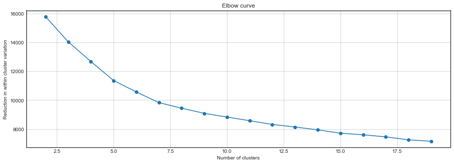

```python
# First, I plot the Elbow Curve in order to see how k influence the variation

from sklearn.cluster import KMeans
from matplotlib import pyplot as plt

within_cluster_variance = [] # initiate empty list with no data

# build models for range of ks from 2 to 20
for k in range(2, 20):
    kmeans = KMeans(n_clusters=k)
    kmeans.fit(X)
    within_cluster_variance.append(kmeans.inertia_)

fig = plt.figure(figsize=(15, 5))
plt.plot(range(2, 20), within_cluster_variance, marker='o')
plt.grid(True)
plt.xlabel('Number of clusters')
plt.ylabel('Reduction in within cluster variation')

plt.title('Elbow curve')  #Choose k at elbow of plot as a general rule.  We want a small enough number of categories to
                          # such that we can still learn something meaningful from them via exploration of our variables.
```

Wikipedia says: "In clustering, this means one should choose a number of clusters so that adding another cluster doesn't give much better modeling of the data." Through the above elbow chart, we can plot reduction within cluster variation for each k. From the plot we can see that, as the number of clusters (k) increases, reduction in the variation decreases.

I want to identify high & low quality of wine, I decide to check k=2,3,4,5,6,7,8,9,12 to see how these k works. I want to get the k, which makes the quality value diverge the most.

```python
# k = 2
km1 = KMeans(n_clusters=2, n_init=20)
km1.fit(X)
X['cluster'] = km1.labels_
display(X.groupby('cluster').mean())
```

| cluster | fixed acidity | volatile acidity | citric acid | residual sugar | chlorides | free sulfur dioxide | total sulfur dioxide | density | pH | sulphates | alcohol | quality |
| --- | --- | --- | --- | --- | --- | --- | --- | --- | --- | --- | --- | --- |
| 0 | 1.056847 | -0.45408 | 0.981265 | 0.286105 | 0.867516 | -0.346654 | -0.223725 | 0.942866 | -0.966021 | 0.564172 | -0.585830 | -0.275680 |
| 1 | -0.158033 | 0.06790 | -0.146731 | -0.042782 | -0.129722 | 0.051836 | 0.033454 | -0.140989 | 0.144452 | -0.084362 | 0.087601 | 0.041223 |

```python
# k = 3
km1 = KMeans(n_clusters=3, n_init=20)
km1.fit(X)
X['cluster'] = km1.labels_
display(X.groupby('cluster').mean())
```

| cluster | fixed acidity | volatile acidity | citric acid | residual sugar | chlorides | free sulfur dioxide | total sulfur dioxide | density | pH | sulphates | alcohol | quality |
| --- | --- | --- | --- | --- | --- | --- | --- | --- | --- | --- | --- | --- |
| 0 | -0.648726 | 0.502795 | -0.794277 | -0.226035 | -0.171836 | -0.238781 | -0.357868 | -0.432851 | 0.614982 | -0.315364 | 0.029221 | -0.153553 |
| 1 | -0.085943 | 0.061126 | 0.156541 | 0.321149 | 0.378175 | 0.970991 | 1.245414 | 0.284229 | -0.274563 | 0.120186 | -0.568203 | -0.416835 |
| 2 | 1.004230 | -0.773807 | 1.013720 | 0.060429 | -0.064568 | -0.457020 | -0.511939 | 0.388432 | -0.658446 | 0.354645 | 0.426435 | 0.564604 |

```python
# k = 4
km1 = KMeans(n_clusters=4, n_init=20)
km1.fit(X)
X['cluster'] = km1.labels_
display(X.groupby('cluster').mean())
```

| cluster | fixed acidity | volatile acidity | citric acid | residual sugar | chlorides | free sulfur dioxide | total sulfur dioxide | density | pH | sulphates | alcohol | quality |
| --- | --- | --- | --- | --- | --- | --- | --- | --- | --- | --- | --- | --- |
| 0 | -0.072287 | 0.078402 | 0.091065 | 0.395294 | -0.005974 | 1.043205 | 1.307421 | 0.314881 | -0.172330 | -0.213706 | -0.562866 | -0.448187 |
| 1 | -0.630230 | 0.499349 | -0.777065 | -0.230389 | -0.169854 | -0.258792 | -0.363502 | -0.413803 | 0.596612 | -0.316293 | 0.016815 | -0.175426 |
| 2 | 0.977739 | -0.795387 | 1.005906 | 0.058483 | -0.079330 | -0.416307 | -0.497132 | 0.357274 | -0.645923 | 0.418054 | 0.457182 | 0.621964 |
| 3 | 0.095416 | 0.002200 | 1.181553 | -0.389872 | 5.784760 | -0.049516 | 0.510330 | 0.180072 | -1.735792 | 3.663412 | -0.869731 | -0.345440 |

```python
# k = 5
km1 = KMeans(n_clusters=5, n_init=20)
km1.fit(X)
X['cluster'] = km1.labels_
display(X.groupby('cluster').mean())
```

| cluster | fixed acidity | volatile acidity | citric acid | residual sugar | chlorides | free sulfur dioxide | total sulfur dioxide | density | pH | sulphates | alcohol | quality |
| --- | --- | --- | --- | --- | --- | --- | --- | --- | --- | --- | --- | --- |
| 0 | 1.633087 | -0.569276 | 1.224593 | 0.167021 | 0.065219 | -0.518117 | -0.460144 | 1.142925 | -0.982142 | 0.235451 | -0.048829 | 0.126665 |
| 1 | -0.625243 | 0.562226 | -0.827525 | -0.216813 | -0.146453 | -0.261622 | -0.369056 | -0.353833 | 0.605408 | -0.334289 | -0.050904 | -0.224127 |
| 2 | 0.147902 | -0.985304 | 0.695171 | -0.082209 | -0.303712 | -0.274931 | -0.468873 | -0.641748 | -0.199399 | 0.448642 | 1.077191 | 1.088810 |
| 3 | -0.095516 | 0.069252 | 0.082105 | 0.373737 | 0.002698 | 1.044592 | 1.299047 | 0.306180 | -0.156289 | -0.164036 | -0.579605 | -0.431998 |
| 4 | 0.081831 | 0.017955 | 1.144178 | -0.399396 | 5.604731 | -0.070479 | 0.474416 | 0.185803 | -1.687357 | 3.720608 | -0.882563 | -0.360695 |

```python
# k = 6
km1 = KMeans(n_clusters=6, n_init=20)
km1.fit(X)
X['cluster'] = km1.labels_
display(X.groupby('cluster').mean())
```

| cluster | fixed acidity | volatile acidity | citric acid | residual sugar | chlorides | free sulfur dioxide | total sulfur dioxide | density | pH | sulphates | alcohol | quality |
| --- | --- | --- | --- | --- | --- | --- | --- | --- | --- | --- | --- | --- |
| 0 | -0.484555 | 0.261734 | -0.665014 | -0.311644 | -0.155230 | -0.213269 | -0.408441 | -0.379766 | 0.266471 | -0.301765 | -0.136359 | -0.031168 |
| 1 | -0.346109 | 0.877025 | -0.617582 | 0.090603 | 0.019559 | 0.213485 | 0.553576 | 0.182165 | 0.255779 | -0.460345 | -0.564926 | -0.703102 |
| 2 | 0.627933 | -0.594133 | 0.720899 | -0.055315 | -0.030352 | 0.284141 | 0.198425 | 0.658273 | -0.345223 | 0.285356 | -0.429645 | -0.272432 |
| 3 | 0.070110 | -0.023904 | 1.390011 | -0.391139 | 6.635415 | -0.079685 | 0.187234 | 0.176665 | -1.597336 | 3.141076 | -0.940690 | -0.426544 |
| 4 | -0.262771 | -0.820475 | 0.415575 | -0.112513 | -0.371774 | -0.120976 | -0.248586 | -1.032213 | 0.187166 | 0.279617 | 1.347123 | 0.986245 |
| 5 | 1.675922 | -0.620400 | 1.352012 | 1.035030 | 0.074957 | -0.283857 | -0.317098 | 1.199379 | -0.935045 | 0.634889 | 0.516599 | 0.871996 |

```python
# k = 7
km1 = KMeans(n_clusters=7, n_init=20)
km1.fit(X)
X['cluster'] = km1.labels_
display(X.groupby('cluster').mean())
```

| cluster | fixed acidity | volatile acidity | citric acid | residual sugar | chlorides | free sulfur dioxide | total sulfur dioxide | density | pH | sulphates | alcohol | quality |
| --- | --- | --- | --- | --- | --- | --- | --- | --- | --- | --- | --- | --- |
| 0 | -1.040068 | 0.301289 | -0.863330 | -0.234076 | -0.401918 | 0.271148 | -0.167265 | -1.262892 | 1.105164 | -0.111514 | 1.135391 | 0.508730 |
| 1 | -0.457501 | 0.643913 | -0.791742 | -0.206453 | -0.052645 | -0.467089 | -0.425950 | -0.012672 | 0.385729 | -0.418888 | -0.502480 | -0.501380 |
| 2 | 0.217372 | -1.016705 | 0.735431 | -0.121366 | -0.274130 | -0.358994 | -0.550919 | -0.556379 | -0.248618 | 0.460185 | 0.995069 | 1.065189 |
| 3 | -0.085633 | -0.034652 | 0.414856 | 4.961768 | 0.296388 | 1.750191 | 1.695832 | 1.225001 | -0.325460 | -0.023789 | -0.363913 | -0.022761 |
| 4 | -0.056448 | 0.060210 | 0.083889 | -0.020765 | -0.032705 | 0.948507 | 1.223314 | 0.252061 | -0.149907 | -0.177883 | -0.592554 | -0.465625 |
| 5 | 1.646516 | -0.570913 | 1.234234 | 0.118369 | 0.072442 | -0.525962 | -0.475019 | 1.129321 | -1.000528 | 0.263158 | -0.022457 | 0.161159 |
| 6 | 0.081831 | 0.017955 | 1.144178 | -0.399396 | 5.604731 | -0.070479 | 0.474416 | 0.185803 | -1.687357 | 3.720608 | -0.882563 | -0.360695 |

```python
# k = 8
km1 = KMeans(n_clusters=8, n_init=20)
km1.fit(X)
X['cluster'] = km1.labels_
display(X.groupby('cluster').mean())
```

| cluster | fixed acidity | volatile acidity | citric acid | residual sugar | chlorides | free sulfur dioxide | total sulfur dioxide | density | pH | sulphates | alcohol | quality |
| --- | --- | --- | --- | --- | --- | --- | --- | --- | --- | --- | --- | --- |
| 0 | 1.577284 | -0.645698 | 1.234260 | 0.167895 | 0.042566 | -0.509347 | -0.465968 | 1.048872 | -0.941211 | 0.378851 | 0.091157 | 0.356942 |
| 1 | -0.040097 | 0.096231 | 0.086947 | 0.011981 | -0.016782 | 0.943552 | 1.260051 | 0.301112 | -0.159326 | -0.223494 | -0.622805 | -0.482919 |
| 2 | -1.094498 | 0.263410 | -0.903354 | -0.256318 | -0.434393 | 0.334044 | -0.118436 | -1.371482 | 1.148137 | -0.073617 | 1.254951 | 0.548272 |
| 3 | -0.269914 | 0.174165 | -0.509374 | -0.345993 | -0.052767 | -0.513234 | -0.445757 | -0.046130 | -0.043698 | -0.348693 | -0.595257 | -0.234630 |
| 4 | -0.655722 | 1.213515 | -1.075871 | -0.070069 | -0.075558 | -0.341576 | -0.378460 | -0.020379 | 0.914221 | -0.452302 | -0.320897 | -0.793303 |
| 5 | 0.024977 | -1.016108 | 0.665285 | -0.131273 | -0.300856 | -0.197151 | -0.477252 | -0.748975 | -0.124416 | 0.404082 | 1.112760 | 1.006874 |
| 6 | -0.185495 | 0.038306 | 0.271620 | 5.110462 | 0.325345 | 1.822776 | 1.838760 | 1.227801 | -0.270564 | -0.088065 | -0.509078 | -0.148509 |
| 7 | 0.095416 | 0.002200 | 1.181553 | -0.389872 | 5.784760 | -0.049516 | 0.510330 | 0.180072 | -1.735792 | 3.663412 | -0.869731 | -0.345440 |

```python
# k = 9
km1 = KMeans(n_clusters=9, n_init=20)
km1.fit(X)
X['cluster'] = km1.labels_
display(X.groupby('cluster').mean())
```

| cluster | fixed acidity | volatile acidity | citric acid | residual sugar | chlorides | free sulfur dioxide | total sulfur dioxide | density | pH | sulphates | alcohol | quality |
| --- | --- | --- | --- | --- | --- | --- | --- | --- | --- | --- | --- | --- |
| 0 | -0.032029 | 0.102180 | 0.092619 | 0.011884 | -0.018050 | 0.941115 | 1.260981 | 0.308694 | -0.162795 | -0.224400 | -0.629007 | -0.497270 |
| 1 | -0.703824 | 1.147697 | -1.069094 | -0.105739 | -0.100839 | -0.252593 | -0.354359 | -0.133752 | 0.952171 | -0.423357 | -0.193603 | -0.701737 |
| 2 | 2.015779 | -0.545040 | 1.317923 | 0.131191 | 0.044308 | -0.456384 | -0.392973 | 1.432084 | -1.228723 | 0.316582 | -0.195068 | 0.101480 |
| 3 | -0.229673 | -1.022500 | 0.502308 | -0.212381 | -0.345366 | -0.044495 | -0.363745 | -0.941728 | 0.048603 | 0.408018 | 1.143285 | 1.010489 |
| 4 | 0.797062 | -0.830243 | 1.012802 | 0.113482 | -0.023133 | -0.583709 | -0.626187 | 0.245092 | -0.520397 | 0.454844 | 0.553305 | 0.746650 |
| 5 | -1.118265 | 0.166591 | -0.871820 | -0.252366 | -0.460734 | 0.396841 | -0.048917 | -1.450963 | 1.175027 | -0.036868 | 1.386876 | 0.660201 |
| 6 | 0.095416 | 0.002200 | 1.181553 | -0.389872 | 5.784760 | -0.049516 | 0.510330 | 0.180072 | -1.735792 | 3.663412 | -0.869731 | -0.345440 |
| 7 | -0.280839 | 0.227312 | -0.559489 | -0.329303 | -0.067126 | -0.531038 | -0.457446 | -0.064328 | -0.053145 | -0.413687 | -0.593939 | -0.240602 |
| 8 | -0.185495 | 0.038306 | 0.271620 | 5.110462 | 0.325345 | 1.822776 | 1.838760 | 1.227801 | -0.270564 | -0.088065 | -0.509078 | -0.148509 |

```python
# k = 12
km1 = KMeans(n_clusters=12, n_init=20)
km1.fit(X)
X['cluster'] = km1.labels_
display(X.groupby('cluster').mean())
```

| cluster | fixed acidity | volatile acidity | citric acid | residual sugar | chlorides | free sulfur dioxide | total sulfur dioxide | density | pH | sulphates | alcohol | quality |
| --- | --- | --- | --- | --- | --- | --- | --- | --- | --- | --- | --- | --- |
| 0 | -0.011580 | 0.532036 | -0.131923 | 0.019706 | 0.066510 | 0.784440 | 1.532693 | 0.265806 | -0.457405 | -0.491146 | -0.733441 | -0.563193 |
| 1 | -0.621754 | 1.191075 | -1.056639 | -0.063006 | -0.038545 | -0.427111 | -0.387464 | 0.058876 | 0.888348 | -0.439623 | -0.400329 | -0.833071 |
| 2 | 1.812007 | -0.655326 | 1.430160 | 0.473015 | 0.022121 | -0.431034 | -0.432125 | 1.113892 | -0.983392 | 0.689575 | 0.645850 | 0.969997 |
| 3 | -0.195132 | 0.015900 | 0.243184 | 5.196591 | 0.311724 | 1.825758 | 1.794095 | 1.193584 | -0.279342 | -0.185786 | -0.490910 | -0.127198 |
| 4 | 0.029831 | -1.000181 | 0.667728 | -0.142740 | -0.295866 | -0.235012 | -0.496723 | -0.769604 | -0.139176 | 0.357694 | 1.127224 | 1.019046 |
| 5 | -1.488038 | 0.090283 | -0.720113 | -0.308695 | -0.673111 | 0.274946 | 0.451483 | -2.089046 | 1.714595 | 0.008739 | 2.225446 | 0.771985 |
| 6 | -0.226462 | 0.155604 | -0.440623 | -0.341349 | -0.049080 | -0.580806 | -0.461590 | -0.016840 | -0.130732 | -0.376087 | -0.639094 | -0.300705 |
| 7 | 0.070110 | -0.023904 | 1.390011 | -0.391139 | 6.635415 | -0.079685 | 0.187234 | 0.176665 | -1.597336 | 3.141076 | -0.940690 | -0.426544 |
| 8 | -0.867065 | 0.390887 | -1.008732 | -0.268012 | -0.310310 | 0.337773 | -0.349431 | -0.923946 | 0.846395 | -0.187044 | 0.618033 | 0.393236 |
| 9 | 1.378762 | -0.636088 | 1.064078 | -0.094292 | 0.037905 | -0.593036 | -0.500346 | 1.018466 | -0.890914 | 0.017891 | -0.447453 | -0.254506 |
| 10 | -0.151723 | -0.625170 | 0.389085 | -0.024435 | -0.138281 | 1.246054 | 0.774960 | 0.261425 | 0.400570 | 0.087267 | -0.388848 | -0.266794 |
| 11 | 0.010263 | 0.027888 | 0.245324 | 0.052285 | 0.205278 | 0.603677 | 1.947153 | 0.541712 | -1.307118 | 4.252489 | -0.590644 | -0.478155 |

To choose which k is the best for my unsupervised learning, I need to be certain that the purpose of my analysis is to segment these wine data using the quality feature. Therefore, I should check which k makes the wine quality most distinct.

However, looking at the number might be a little bit of difficult, so I draw a scatter plot to make it more convenient to see.

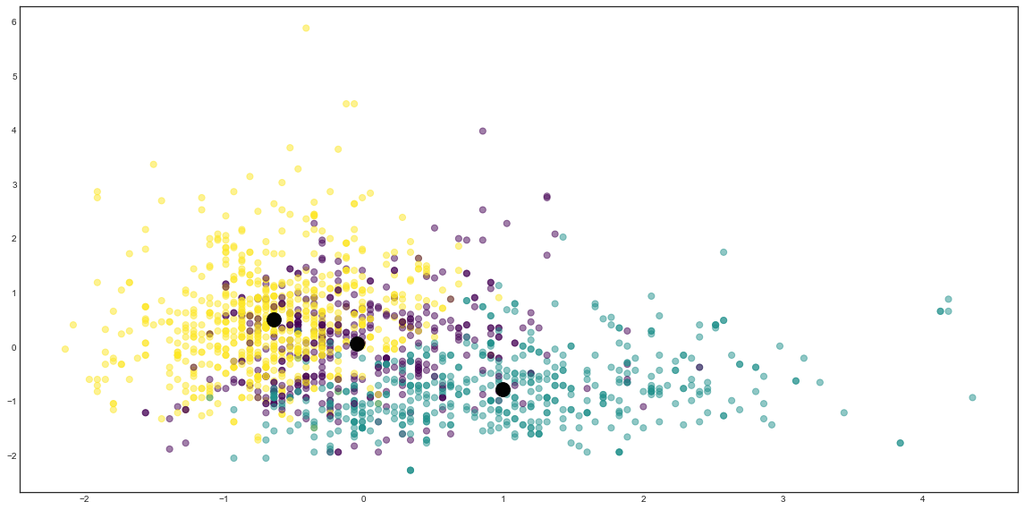

```python
from sklearn.cluster import KMeans
kmeans = KMeans(n_clusters=3)
kmeans.fit(X)
y_kmeans = kmeans.predict(X)

plt.figure(figsize=(20, 10))
#plot original data colored by k-means clusters from model
plt.scatter(X.iloc[:, 0], X.iloc[:, 1], c=y_kmeans, s=50, cmap='viridis',alpha=0.5)

centers = kmeans.cluster_centers_ # extract final centroids from each cluster
plt.scatter(centers[:, 0], centers[:, 1], c='black', s=250, alpha=0.99);
```

## Answer for Question 1) K-means

### --- From the analysis above, we can see that the variables that cluster with higher values of wine quality includes: fixed acidity, citric, density, sulphates and alcohol. From the analysis above, we can see that the variables that cluster with lower values of wine quality includes: residual sugar, chlorides, free sulfur dioxide and total sulfur dioxide.

### --- If I want to make good wines, according to the K-means model, I need to make sure it has high fixed acidity, citric, density, sulphates and alcohol. At the same time, I will need to lower residual sugar, chlorides, free sulfur dioxide and total sulfur dioxide.

## 2. Use Hierarchical Cluster Analysis to identify cluster(s) of observations that have high and low values of the wine quality. (Assume all variables are continuous.) Use complete linkage and the same number of groups that you found to be the most meaningful in question 1. ------- Describe variables that cluster with higher values of wine quality. Describe variables that cluster with lower values of wine quality. ----- If you want to make a good bottle of wine, then what characteristics are most important according to this analysis? ----- Have your conclusions changed using Hierarchical clustering rather than k means clustering? Present any figures that assist you in your analysis.

### First, I will analyze this in the complete linkage, but i found ward linkage might be a bbetter option, so i will analyze agin using ward linkage.

```python
from sklearn.cluster import AgglomerativeClustering

X = pd.DataFrame(scale(df), index=df.index, columns=df.columns)
ac = AgglomerativeClustering(n_clusters=3,   # note that we select the clusters
                             affinity='euclidean',
                             linkage='complete')
labels = ac.fit_predict(X)
print(*labels)
```

[output not shown]

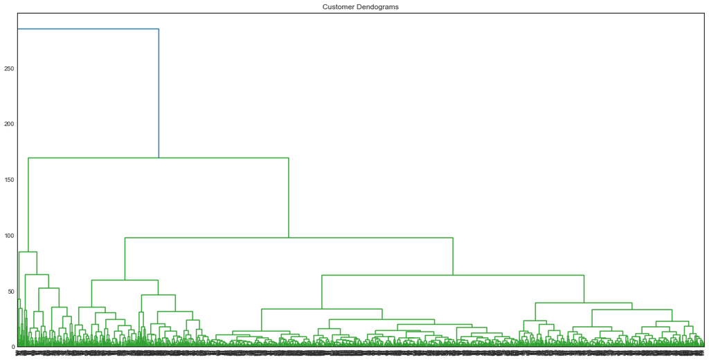

```python
import scipy.cluster.hierarchy as shc

plt.figure(figsize=(20, 10))
plt.title("Customer Dendograms")
dend = shc.dendrogram(shc.linkage(df, method='complete'))
```

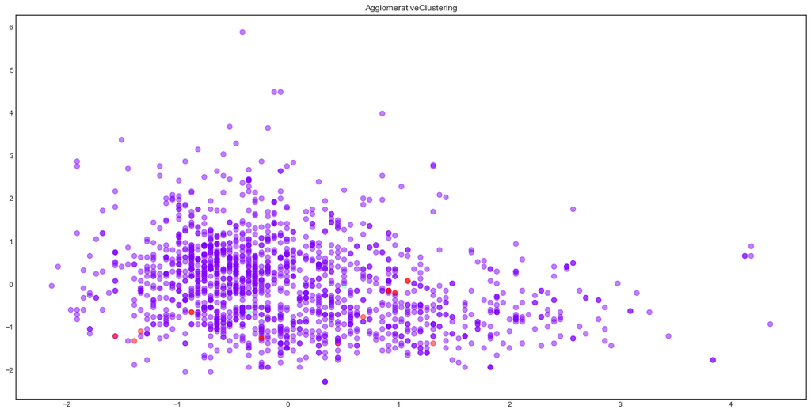

```python
# Hierarchical Cluster Analysis
plt.figure(figsize=(20, 10))

ac = AgglomerativeClustering(n_clusters=3,
                             affinity='euclidean',
                             linkage='complete')
y_ac = ac.fit_predict(X)

plt.scatter(X.iloc[:, 0], X.iloc[:, 1], c=y_ac, s=50, cmap='rainbow',alpha=0.5)

plt.title('AgglomerativeClustering')
```

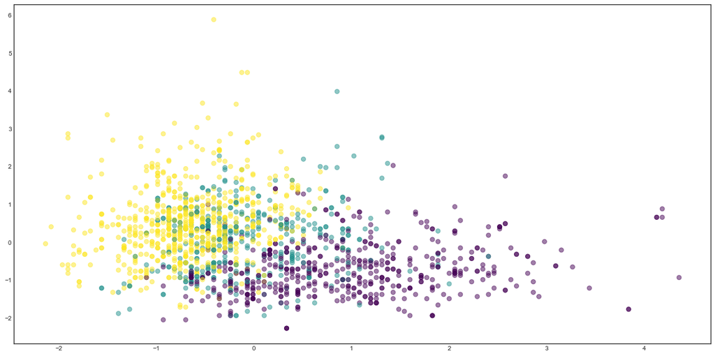

```python
from sklearn.cluster import KMeans
kmeans = KMeans(n_clusters=3)
kmeans.fit(X)
y_kmeans = kmeans.predict(X)

plt.figure(figsize=(20, 10))
#plot original data colored by k-means clusters from model
plt.scatter(X.iloc[:, 0], X.iloc[:, 1], c=y_kmeans, s=50, cmap='viridis',alpha=0.5)
```

```python
# k = 3
ac = AgglomerativeClustering(n_clusters=3,
                             affinity='euclidean',
                             linkage='complete')
y_ac = ac.fit_predict(X)
X['cluster'] = y_ac
display(X.groupby('cluster').mean())
```

| cluster | fixed acidity | volatile acidity | citric acid | residual sugar | chlorides | free sulfur dioxide | total sulfur dioxide | density | pH | sulphates | alcohol | quality |
| --- | --- | --- | --- | --- | --- | --- | --- | --- | --- | --- | --- | --- |
| 0 | -0.001252 | 0.007812 | -0.011733 | -0.066281 | -0.018035 | -0.014593 | -0.015860 | -0.014375 | 0.009877 | -0.006656 | 0.003986 | -0.001216 |
| 1 | 0.074897 | -0.350945 | 3.127368 | 0.043416 | 11.116408 | 0.394484 | 0.320274 | 0.770280 | -2.663717 | 5.735193 | -0.960246 | -1.407158 |
| 2 | 0.114396 | -0.728032 | 0.768457 | 6.544008 | 0.392577 | 1.392631 | 1.527129 | 1.324144 | -0.642992 | -0.059154 | -0.273842 | 0.296014 |

## Answer for Question 2) Hierarchical Cluster Analysis, K = 3 and Linkage = "complete"

### --- By comparing the scatter plots for the K-means model and the Hierarchical Cluster Analysis Model, as well as the feature analysis, I have to say that these two models are pretty different in predicting "good quality wines".

## Optional Analysis - As I mention above, I fell "ward" linkage would be a better option, so I condcut the same analysis using "ward" linkage again here

```python
from sklearn.cluster import AgglomerativeClustering

X = pd.DataFrame(scale(df), index=df.index, columns=df.columns)
ac = AgglomerativeClustering(n_clusters=3,   # note that we select the clusters
                             affinity='euclidean',
                             linkage='ward')
labels = ac.fit_predict(X)
print(*labels)
```

[output not shown]

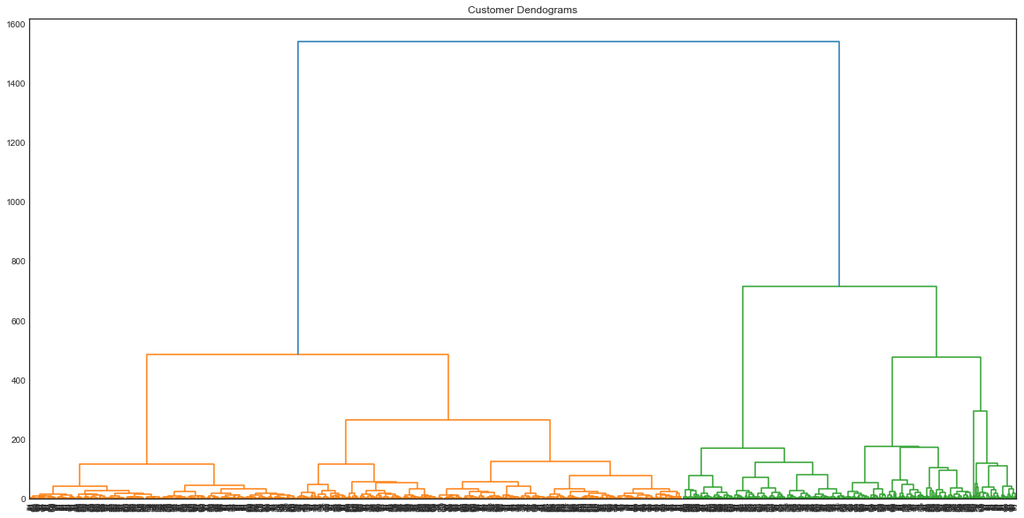

```python
import scipy.cluster.hierarchy as shc

plt.figure(figsize=(20, 10))
plt.title("Customer Dendograms")
dend = shc.dendrogram(shc.linkage(df, method='ward'))
```

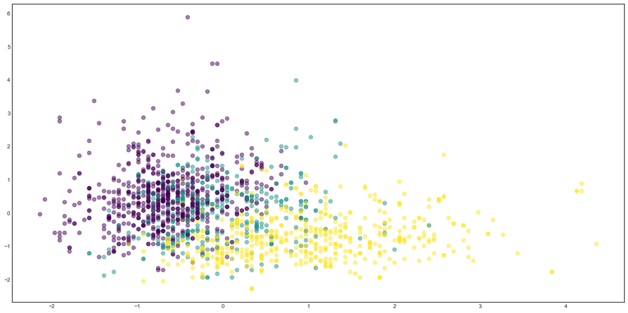

```python
from sklearn.cluster import KMeans
kmeans = KMeans(n_clusters=3)
kmeans.fit(X)
y_kmeans = kmeans.predict(X)

plt.figure(figsize=(20, 10))
#plot original data colored by k-means clusters from model
plt.scatter(X.iloc[:, 0], X.iloc[:, 1], c=y_kmeans, s=50, cmap='viridis',alpha=0.5)
```

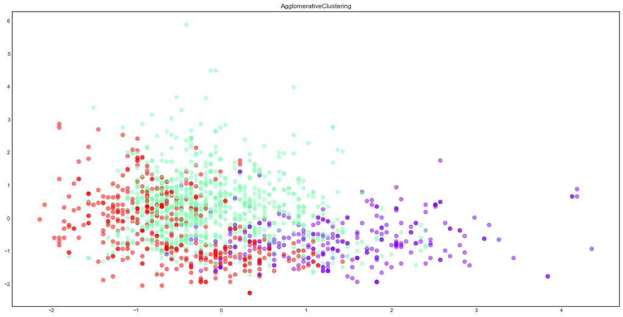

```python
plt.figure(figsize=(20, 10))

ac = AgglomerativeClustering(n_clusters=3,
                             affinity='euclidean',
                             linkage='ward')
y_ac = ac.fit_predict(X)

plt.scatter(X.iloc[:, 0], X.iloc[:, 1], c=y_ac, s=50, cmap='rainbow',alpha=0.5)

plt.title('AgglomerativeClustering')
```

```python
# k = 3
ac = AgglomerativeClustering(n_clusters=3,
                             affinity='euclidean',
                             linkage='ward')
y_ac = ac.fit_predict(X)
X['cluster'] = y_ac
display(X.groupby('cluster').mean())
```

| cluster | fixed acidity | volatile acidity | citric acid | residual sugar | chlorides | free sulfur dioxide | total sulfur dioxide | density | pH | sulphates | alcohol | quality |
| --- | --- | --- | --- | --- | --- | --- | --- | --- | --- | --- | --- | --- |
| 0 | 1.389705 | -0.659783 | 1.274489 | 0.192005 | 0.500494 | -0.642297 | -0.586717 | 0.793481 | -0.974214 | 0.672761 | 0.254951 | 0.567704 |
| 1 | -0.133969 | 0.304452 | -0.263487 | 0.050987 | 0.015598 | 0.082881 | 0.252669 | 0.240800 | 0.031466 | -0.225128 | -0.536115 | -0.449637 |
| 2 | -0.595178 | -0.258313 | -0.230027 | -0.238304 | -0.357732 | 0.228003 | -0.189132 | -1.052387 | 0.557478 | 0.071804 | 1.039591 | 0.643731 |

### --- Actually, it is still pretty different than the K-means Model

## 3. Use Principal Components Analysis to reduce the dimensions of your data. ----- How much of the variation in your data is explained by the first two principal components. ----- How might you use the first two components to do supervised learning on some other variable tied to wine (e.g. - wine price)?

```python
# prep data
X = pd.DataFrame(scale(df), index=df.index, columns=df.columns)
PCA().fit(X).components_.T
```

```
array([[ 0.48788336, -0.00417321, -0.16482854, -0.23109808, -0.07877938,
         0.0555313 , -0.30721496,  0.20052866, -0.17457815, -0.18295601,
        -0.25643792,  0.63857976],
       [-0.26512898,  0.33896786, -0.22708884,  0.04185824,  0.29937933,
         0.297287  , -0.62623369,  0.14612614, -0.06022334,  0.15510563,
         0.37716123,  0.00466168],
       [ 0.47333547, -0.1373581 ,  0.10022856, -0.0567358 , -0.12014871,
         0.13663328,  0.24414858,  0.29633271, -0.22097505,  0.34608556,
         0.62432783, -0.07003691],
       [ 0.13915442,  0.16773634,  0.24362014, -0.38303758,  0.70936319,
         0.10931059,  0.28385429, -0.17062614,  0.27818728, -0.05223656,
         0.08807787,  0.18364637],
       [ 0.19742679,  0.18978819, -0.02660785,  0.65477782,  0.26623723,
         0.33733656,  0.23054697, -0.18692254, -0.41993639, -0.00386273,
        -0.20861667,  0.05393118],
       [-0.04588071,  0.25948314,  0.61611132, -0.03371148, -0.15941286,
        -0.04264807, -0.13826041, -0.01935607, -0.31800012, -0.58538858,
         0.23793317, -0.05192167],
       [ 0.00406675,  0.36397137,  0.54073214, -0.02845973, -0.21845284,
         0.1159536 , -0.11020865,  0.08989655,  0.12182276,  0.58918824,
        -0.35504684,  0.06979295],
       [ 0.37030119,  0.33078079, -0.16872267, -0.20069341,  0.20879298,
        -0.42566742, -0.12254646,  0.07950023, -0.24907449,  0.0435381 ,
        -0.23145306, -0.56664499],
       [-0.43272085, -0.06544015,  0.06977056, -0.00546618,  0.25764682,
        -0.48035396,  0.18569166,  0.31469303, -0.46191598,  0.20760989,
        -0.00559907,  0.34123006],
       [ 0.25453535, -0.10933362,  0.21291324,  0.56050237,  0.21483493,
        -0.40374303, -0.23340206,  0.27549158,  0.45268884, -0.07191857,
         0.09763703,  0.06779298],
       [-0.07317678, -0.50270865,  0.22497138, -0.09170143,  0.25972635,
         0.39217625, -0.12171879,  0.47118865, -0.09652795, -0.11060525,
        -0.3199487 , -0.31764032],
       [ 0.11248878, -0.47316621,  0.22336929, -0.03666923,  0.13758414,
        -0.14183046, -0.41238785, -0.61224719, -0.24024309,  0.26023979,
         0.05246571,  0.00847048]])
```

```python
# The loading vectors
pca_loadings = pd.DataFrame(PCA().fit(X).components_.T, index=df.columns, columns=['V1', 'V2', 'V3', 'V4','V5', 'V6', 'V7', 'V8','V9', 'V10', 'V11', 'V12'])
pca_loadings
```

|  | V1 | V2 | V3 | V4 | V5 | V6 | V7 | V8 | V9 | V10 | V11 | V12 |
| --- | --- | --- | --- | --- | --- | --- | --- | --- | --- | --- | --- | --- |
| fixed acidity | 0.487883 | -0.004173 | -0.164829 | -0.231098 | -0.078779 | 0.055531 | -0.307215 | 0.200529 | -0.174578 | -0.182956 | -0.256438 | 0.638580 |
| volatile acidity | -0.265129 | 0.338968 | -0.227089 | 0.041858 | 0.299379 | 0.297287 | -0.626234 | 0.146126 | -0.060223 | 0.155106 | 0.377161 | 0.004662 |
| citric acid | 0.473335 | -0.137358 | 0.100229 | -0.056736 | -0.120149 | 0.136633 | 0.244149 | 0.296333 | -0.220975 | 0.346086 | 0.624328 | -0.070037 |
| residual sugar | 0.139154 | 0.167736 | 0.243620 | -0.383038 | 0.709363 | 0.109311 | 0.283854 | -0.170626 | 0.278187 | -0.052237 | 0.088078 | 0.183646 |
| chlorides | 0.197427 | 0.189788 | -0.026608 | 0.654778 | 0.266237 | 0.337337 | 0.230547 | -0.186923 | -0.419936 | -0.003863 | -0.208617 | 0.053931 |
| free sulfur dioxide | -0.045881 | 0.259483 | 0.616111 | -0.033711 | -0.159413 | -0.042648 | -0.138260 | -0.019356 | -0.318000 | -0.585389 | 0.237933 | -0.051922 |
| total sulfur dioxide | 0.004067 | 0.363971 | 0.540732 | -0.028460 | -0.218453 | 0.115954 | -0.110209 | 0.089897 | 0.121823 | 0.589188 | -0.355047 | 0.069793 |
| density | 0.370301 | 0.330781 | -0.168723 | -0.200693 | 0.208793 | -0.425667 | -0.122546 | 0.079500 | -0.249074 | 0.043538 | -0.231453 | -0.566645 |
| pH | -0.432721 | -0.065440 | 0.069771 | -0.005466 | 0.257647 | -0.480354 | 0.185692 | 0.314693 | -0.461916 | 0.207610 | -0.005599 | 0.341230 |
| sulphates | 0.254535 | -0.109334 | 0.212913 | 0.560502 | 0.214835 | -0.403743 | -0.233402 | 0.275492 | 0.452689 | -0.071919 | 0.097637 | 0.067793 |
| alcohol | -0.073177 | -0.502709 | 0.224971 | -0.091701 | 0.259726 | 0.392176 | -0.121719 | 0.471189 | -0.096528 | -0.110605 | -0.319949 | -0.317640 |
| quality | 0.112489 | -0.473166 | 0.223369 | -0.036669 | 0.137584 | -0.141830 | -0.412388 | -0.612247 | -0.240243 | 0.260240 | 0.052466 | 0.008470 |

```python
# Fit the PCA model and transform X to get the principal components
pca = PCA()
df_plot = pd.DataFrame(pca.fit_transform(X), columns=['PC1', 'PC2', 'PC3', 'PC4','PC5', 'PC6', 'PC7', 'PC8','PC9', 'PC10', 'PC11', 'PC12'], index=X.index)
df_plot
```

|  | PC1 | PC2 | PC3 | PC4 | PC5 | PC6 | PC7 | PC8 | PC9 | PC10 | PC11 | PC12 |
| --- | --- | --- | --- | --- | --- | --- | --- | --- | --- | --- | --- | --- |
| 0 | -1.779442 | 1.157303 | -1.386581 | -0.044944 | 0.233885 | -0.976983 | -0.110528 | 0.040320 | -0.294420 | 0.073112 | -0.262937 | 0.048362 |
| 1 | -1.004185 | 2.071838 | 0.007759 | 0.466119 | 0.182454 | 0.657775 | -1.376790 | -0.176714 | 0.587342 | -0.565736 | 0.048784 | -0.139565 |
| 2 | -0.915783 | 1.393434 | -0.699286 | 0.345292 | 0.095210 | 0.254823 | -0.720338 | -0.088687 | 0.546495 | -0.162065 | -0.199140 | -0.120391 |
| 3 | 2.404077 | -0.213792 | 0.066381 | -0.889182 | -1.524742 | -0.132218 | 0.200660 | -0.202816 | -0.506212 | 0.241135 | -0.107616 | 0.319764 |
| 4 | -1.779442 | 1.157303 | -1.386581 | -0.044944 | 0.233885 | -0.976983 | -0.110528 | 0.040320 | -0.294420 | 0.073112 | -0.262937 | 0.048362 |
| ... | ... | ... | ... | ... | ... | ... | ... | ... | ... | ... | ... | ... |
| 1594 | -2.241991 | 0.599594 | 0.795827 | 0.441059 | -0.312981 | 0.130820 | 0.291926 | 0.137412 | -0.421817 | -1.016843 | 0.312767 | -0.058920 |
| 1595 | -2.122456 | -0.370101 | 2.138539 | 0.454564 | 0.104124 | -0.751228 | -0.436849 | 0.181539 | -0.413852 | -0.992136 | 0.465027 | -0.240933 |
| 1596 | -1.366265 | -0.517561 | 1.250696 | 0.514505 | 0.195916 | -0.552162 | -0.196039 | -0.121154 | -0.107569 | -0.752854 | 0.235266 | -0.402292 |
| 1597 | -2.367147 | 0.703545 | 0.899482 | 0.661956 | 0.021380 | -0.805753 | 0.126669 | 0.607400 | -0.378298 | -0.723453 | 0.737253 | 0.036187 |
| 1598 | -0.288776 | -1.240846 | 1.218095 | -0.306325 | 0.231121 | -0.202925 | 1.443414 | -0.115422 | 0.165194 | 0.305877 | 0.777246 | -0.449167 |

1599 rows × 12 columns

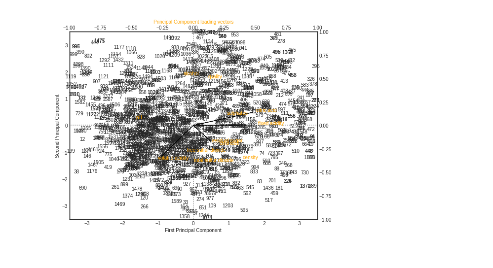

```python
fig , ax1 = plt.subplots(figsize=(9,7))

ax1.set_xlim(-3.5,3.5)
ax1.set_ylim(-3.5,3.5)

# Plot Principal Components 1 and 2
for i in df_plot.index:
    ax1.annotate(i, (df_plot.PC1.loc[i], -df_plot.PC2.loc[i]), ha='center')

# Plot reference lines
ax1.hlines(0,-3.5,3.5, linestyles='dotted', colors='grey')
ax1.vlines(0,-3.5,3.5, linestyles='dotted', colors='grey')

ax1.set_xlabel('First Principal Component')
ax1.set_ylabel('Second Principal Component')

# Plot Principal Component loading vectors, using a second y-axis.
ax2 = ax1.twinx().twiny()

ax2.set_ylim(-1,1)
ax2.set_xlim(-1,1)
ax2.tick_params(axis='y', colors='orange')
ax2.set_xlabel('Principal Component loading vectors', color='orange')

# Plot labels for vectors. Variable 'a' is a small offset parameter to separate arrow tip and text.
a = 1.07
for i in pca_loadings[['V1', 'V2']].index:
    ax2.annotate(i, (pca_loadings.V1.loc[i]*a, -pca_loadings.V2.loc[i]*a), color='orange')

# Plot vectors
ax2.arrow(0,0,pca_loadings.V1[0], -pca_loadings.V2[0])
ax2.arrow(0,0,pca_loadings.V1[1], -pca_loadings.V2[1])
ax2.arrow(0,0,pca_loadings.V1[2], -pca_loadings.V2[2])
ax2.arrow(0,0,pca_loadings.V1[3], -pca_loadings.V2[3]);
```

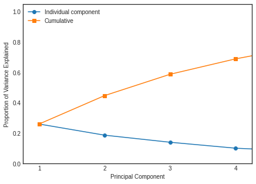

```python
plt.figure(figsize=(7,5))

plt.plot([1,2,3,4,5,6,7,8,9,10,11,12], pca.explained_variance_ratio_, '-o', label='Individual component')
plt.plot([1,2,3,4,5,6,7,8,9,10,11,12], np.cumsum(pca.explained_variance_ratio_), '-s', label='Cumulative')

plt.ylabel('Proportion of Variance Explained')
plt.xlabel('Principal Component')
plt.xlim(0.75,4.25)
plt.ylim(0,1.05)
plt.xticks([1,2,3,4])
plt.legend(loc=2);
```

```python
from sklearn.decomposition import PCA
pca = PCA(n_components=2)
pca.fit(data)
```

```
PCA(copy=True, iterated_power='auto', n_components=2, random_state=None,
    svd_solver='auto', tol=0.0, whiten=False)
```

```python
print(pca.components_)
```

```
[[ 0.48788336 -0.26512898  0.47333547  0.13915442  0.19742679 -0.04588071
   0.00406675  0.37030119 -0.43272085  0.25453535 -0.07317678  0.11248878]
 [-0.00417321  0.33896786 -0.1373581   0.16773634  0.18978819  0.25948314
   0.36397137  0.33078079 -0.06544015 -0.10933362 -0.50270865 -0.47316621]]
```

```python
from sklearn.decomposition import PCA
pca = PCA(n_components=2)
pca.fit(X)
X_pca = pca.transform(X) # create X data with single pca vector
print("original shape:   ", X.shape)
print("transformed shape:", X_pca.shape)
```

```
original shape:    (1599, 12)
transformed shape: (1599, 2)
```

## Answer for Quesntion 3 - PCA

### - The first principal component places more positive weight on variable fixed acidity and places negative weights on variable pH. The second principal component places positive weight on variable total sulfur dioxide and negative weight on variables alcohol and quality.

### - PCA is useful for decresing the dimension of a dataframe. In addition, principal components can be directly used as the features when doing supervised learninf. If we want to build a supervised learning model for wine price using the frist two principal components, we can certainly use the two principal components as the independent features to build supervised learning models.